# Group12 - Project1

Hitesh Prabhu, Zack Bilderback, Michael Lundy, Nicole Erich

February 7, 2017

## Question 1:

First, formulate the dedicated portfolio construction problem.

#### Decision Variables:

$$x_1, x_2, \dots, x_{10}$$

Where $x_n$ is the number of bonds of type $n$ to purchase at time $t=0$.

#### Objective:

$$\textrm{min} \quad 102x_1+99x_2+101x_3+98x_4+98x_5+104x_6+100x_7+101x_8+102x_9+94x_{10}$$

## Question 2:

Solve the test case using R.

```r
library(lpSolveAPI)

# Create an LP model with 0 constraints 10 decision variables
modLP<-make.lp(0,10)

# Set objective coefficients
set.objfn(modLP, c(102,99,101,98,98,104,100,101,102,94))

# Set objective direction
lp.control(modLP,sense='min')

# Add constraints
add.constraint(modLP,c(105,3.5,5,3.5,4,9,6,8,9,7), ">=",12000)
add.constraint(modLP,c(0,103.5,105,3.5,4,9,6,8,9,7), ">=",18000)
add.constraint(modLP,c(0,0,0,103.5,4,9,6,8,9,7), ">=",20000)
add.constraint(modLP,c(0,0,0,0,104,9,6,8,9,7), ">=",20000)
add.constraint(modLP,c(0,0,0,0,0,109,106,8,9,7), ">=",16000)
add.constraint(modLP,c(0,0,0,0,0,0,0,108,9,7), ">=",15000)
add.constraint(modLP,c(0,0,0,0,0,0,0,0,109,7), ">=",12000)
add.constraint(modLP,c(0,0,0,0,0,0,0,0,0,107), ">=",10000)

# Rename variables and constraints
varNames = c("X1","X2","X3","X4","X5","X6","X7","X8","X9","X10")
constraintNames = c("Year1","Year2","Year3","Year4","Year5","Year6","Year7","Year8")
dimnames(modLP) = list(constraintNames, varNames)
```

```r
# Finding 0 is successfully finding an optimal solution
solve(modLP)
```

```
## [1] 0
```

```r
# Show the optimal solution value and variables
optimal = paste("$",formatC(get.objective(modLP),format="f",digits=2,big.mark=","))
print(optimal)
```

```
## [1] "$ 93,944.50"
```

```r
# Display results in a formatted table
vars = round(get.variables(modLP),2)
vars_matrix = matrix(data=vars,nrow=1,ncol=10)
colnames(vars_matrix) = varNames
rownames(vars_matrix) = c("Bond Qty")
kable(vars_matrix)
```

|  | X1 | X2 | X3 | X4 | X5 | X6 | X7 | X8 | X9 | X10 |
| --- | --- | --- | --- | --- | --- | --- | --- | --- | --- | --- |
| Bond Qty | 62.14 | 0 | 125.24 | 151.51 | 156.81 | 123.08 | 0 | 124.16 | 104.09 | 93.46 |

This solution is very close to the provided solution: 63 of bond1, 126 of bond3, 152 of bond4, 157 of bond5, 124 of bond6, 125 of bond8, 105 of bond9, and 94 of bond10.

## Question 3:

Code for the function called dedicate_g12.m is available as a separate file, named dedicate_g12.R.

By running the code below, we test the function.

```r
# ----------
# Test Case
# ----------

# Input vectors

# Prices P
P <- c(102, 99, 101, 98, 98, 104, 100, 101, 102, 94)

# Coupon Rates C
C <- c(5, 3.5, 5, 3.5, 4, 9, 6, 8, 9, 7)

# Maturity M
M <- c(1, 2, 2, 3, 4, 5, 5, 6, 7, 8)

# Liabilities for time t => L
L <- c(12, 18, 20, 20, 16, 15, 12 ,10)*1000

# Function Call
model = dedicate_g12.m(P, C, M, L)

# Show the optimal solution value
optimal = paste("$",formatC(get.objective(model),format="f",digits=2,big.mark=","))
print(optimal)
```

```
## [1] "$ 93,944.50"
```

```r
# Show optimal variables in a formatted table
vars = round(get.variables(model),2)
vars_matrix = matrix(data=vars,nrow=1,ncol=10)
colnames(vars_matrix) = varNames
rownames(vars_matrix) = c("Bond Qty")
kable(vars_matrix)
```

|  | X1 | X2 | X3 | X4 | X5 | X6 | X7 | X8 | X9 | X10 |
| --- | --- | --- | --- | --- | --- | --- | --- | --- | --- | --- |
| Bond Qty | 62.14 | 0 | 125.24 | 151.51 | 156.81 | 123.08 | 0 | 124.16 | 104.09 | 93.46 |

We obtain the same results as the manual method in question 2.

## Question 4:

Finally, construct a dedicated portfolio using this liability stream and the current bond information from the Wall Street Journal (WSJ) Online U.S. Treasury Quotes.

We first saved the bonds from the website into an Excel spreadsheet named “Bonds.xlsx”. We then used the following code to format the dates and select only bonds that will mature at the semi-annual periods (6/30 or 12/31) throughout the timeframe of 2017-2022.

```r
# Read in bond information and store as data frame
library(readxl)
bonds = read_excel("Bonds.xlsx")
bonds$Maturity <- as.Date(bonds$Maturity)


# Filter dataframe to only contain bonds that mature/pay coupons at the specified liability dates
dates = as.Date(c("2017-06-30","2017-12-31","2018-06-30","2018-12-31","2019-06-30","2019-12-31","2020-06-30","2020-12-31","2021-06-30","2021-12-31","2022-06-30","2022-12-31"))
bonds = bonds[bonds$Maturity %in% dates,]

# Prices
P = bonds$Asked

# Coupons
C = bonds$Coupon/2

# Maturities (in periods/half-years)
## Assign each date to period number
periods = seq_along(dates)
names(periods) = dates

## Initialize maturities vector with zeros
M = rep(0,length(bonds$Maturity))

## Add period number corresponding to each maturity date to maturities vector
for (i in seq_along(M)){
  date = toString(bonds$Maturity[i])
  period = periods[date]

  M[i] = period
}

# Liabilities for time t => L
L = c(9,9,10,10,6,6,9,9,10,10,5,3)*1000000
```

```r
# Function Call
model = dedicate_g12.m(P, C, M, L)

# Show the optimal solution value
optimal = paste("$",formatC(get.objective(model),format="f",digits=2,big.mark=","))
print(optimal)
```

```
## [1] "$ 91,442,287.53"
```

```r
# Map back to bonds
results = bonds[,c('Maturity','Coupon','Asked')]
results$Amount = get.variables(model)

# Print as a table
kable(results, digits=2)
```

|  | Maturity | Coupon | Asked | Amount |
| --- | --- | --- | --- | --- |
| 20 | 2017-06-30 | 0.62 | 100.03 | 0.00 |
| 21 | 2017-06-30 | 0.75 | 100.07 | 0.00 |
| 22 | 2017-06-30 | 2.50 | 100.76 | 80551.29 |
| 43 | 2017-12-31 | 0.75 | 99.94 | 0.00 |
| 44 | 2017-12-31 | 1.00 | 100.19 | 0.00 |
| 45 | 2017-12-31 | 2.75 | 101.73 | 81558.18 |
| 69 | 2018-06-30 | 0.62 | 99.55 | 0.00 |
| 70 | 2018-06-30 | 1.38 | 100.59 | 0.00 |
| 71 | 2018-06-30 | 2.38 | 101.94 | 92679.61 |
| 94 | 2018-12-31 | 1.25 | 100.20 | 0.00 |
| 95 | 2018-12-31 | 1.38 | 100.46 | 0.00 |
| 96 | 2018-12-31 | 1.50 | 100.67 | 93780.18 |
| 117 | 2019-06-30 | 1.00 | 99.34 | 0.00 |
| 118 | 2019-06-30 | 1.62 | 100.78 | 54483.53 |
| 138 | 2019-12-31 | 1.12 | 99.24 | 0.00 |
| 139 | 2019-12-31 | 1.62 | 100.63 | 54926.21 |
| 155 | 2020-06-30 | 1.62 | 100.25 | 85372.48 |
| 156 | 2020-06-30 | 1.88 | 101.13 | 0.00 |
| 170 | 2020-12-31 | 1.75 | 100.29 | 0.00 |
| 171 | 2020-12-31 | 2.38 | 102.70 | 86066.13 |
| 186 | 2021-06-30 | 1.12 | 97.23 | 0.00 |
| 187 | 2021-06-30 | 2.12 | 101.45 | 97088.17 |
| 202 | 2021-12-31 | 2.00 | 100.71 | 0.00 |
| 203 | 2021-12-31 | 2.12 | 101.23 | 98119.73 |
| 212 | 2022-06-30 | 2.12 | 100.91 | 49162.25 |
| 222 | 2022-12-31 | 2.12 | 100.45 | 29684.60 |

The “Amount” column above is the number of bonds of each type that we recommend purchasing at time $t=0$ to create a portfolio to finance the liabilities stream.

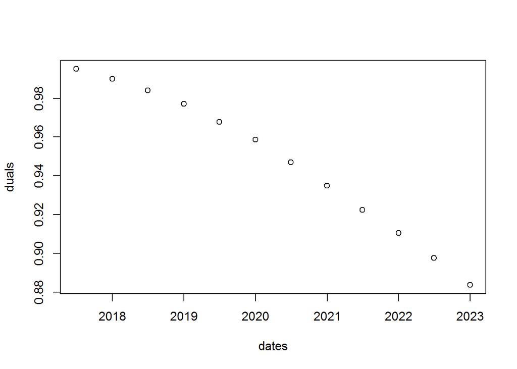

```r
# get.sensitivity.rhs returns three list of duals, we want the first list and only the first twelve which correspond to the liability constraints
duals = get.sensitivity.rhs(model)[[1]][1:12]
plot(dates, duals)
```

The duals here represent the time value of money at the time the portfolio was constructed. As time moves forward, the value of money decreases. This is intuitive because a dollar today is worth more than a dollar tomorrow. This is why we see the decline in the duals.

```r
# Get sensitivity ranges for each dual of the first twelve liability constraints
sens = get.sensitivity.rhs(model)[2:3]
sens_matrix = matrix(data=c(sens$dualsfrom,sens$dualstill),nrow=length(sens$dualsfrom),ncol=2)
sens_matrix = sens_matrix[1:12,]
colnames(sens_matrix) = c("Duals From","Duals To")

rows = c("",12)
for(i in 1:12){
  rows[i] = paste("Liability Constraint ",i)
}

rownames(sens_matrix) = rows
kable(sens_matrix)
```

|  | Duals From | Duals To |
| --- | --- | --- |
| Liability Constraint 1 | 844181.92 | 1.000000e+30 |
| Liability Constraint 2 | 732039.42 | 6.103062e+08 |
| Liability Constraint 3 | 621982.39 | 7.145173e+08 |
| Liability Constraint 4 | 551647.26 | 1.133852e+09 |
| Liability Constraint 5 | 507379.39 | 1.051831e+09 |
| Liability Constraint 6 | 462751.85 | 6.875075e+08 |
| Liability Constraint 7 | 393386.71 | 6.960447e+08 |
| Liability Constraint 8 | 291183.17 | 4.846655e+08 |
| Liability Constraint 9 | 188026.99 | 5.472746e+08 |
| Liability Constraint 10 | 83774.78 | 5.529832e+08 |
| Liability Constraint 11 | 31539.89 | 5.537524e+08 |
| Liability Constraint 12 | 0.00 | 4.755882e+08 |

We can interpret the “duals from” and “duals to” values as the applicable range for the duals of each constraint. For example, for Liability Constraint 2, we found the dual to be approximately .990. This is only true if the libaility due on 12/31/2017 stays between $732,039.42 and $610,306,200. These are fairly wide ranges, so as liabilities change throughout the project planning process, the firm’s internal interest rates will stay fairly stable.